# info_01_exercises

## Psychoinformatics - Week 1 (Exercises)

by Cheng-Kuang Wu (r10922186@ntu.edu.tw)

## 1 Validating the findings about power poses (8 points)

Do [power poses](https://www.youtube.com/watch?v=Ks-_Mh1QhMc) really work? Let's analyze the data (keller2017.csv) from:

Keller, V. N., Johnson, D. J., & Harder, J. A. (2017). [Meeting your inner super (wo)man: are power poses effective when taught?](https://www.tandfonline.com/doi/abs/10.1080/23743603.2017.1341186) Comprehensive Results in Social Psychology, 2(1), 106-122.

where

4 experimental conditions were AC (Aware-Constrictive), AE (Aware-Expansive), UC (Unaware-Constrictive), & UE (Unaware-Expansive)  
and  
3 dependent measures were body expansiveness, performance (in a job interview), & hireability scored by 4 independent raters.

Please construct 3 pandas dataframes df1, and df2, and df3 where  
**df1**, derived from df, has only 13 columns of interest (cond, expansiveness1-4, performance1-4, hire1-4) and no missing values (2 points) ;  
**df2**, derived from df1, has 4 columns that average expansiveness1-4 into "expansiveness", "performance1-4" into "performance", & hire1-4 into "hire" (df1 & df2 should have the same number of rows) (2 points) ;  
**df3**, derived from df2, calculates the means of each dependent variable in each condition (2 points) ;

Finally, run three two-way ANOVAs to see if there is any statistically significant result for each dependent measure (2 point). See [this page](https://www.statology.org/two-way-anova-python/) for an example.

```python
import pandas as pd
df = pd.read_csv("./keller2017.csv")
```

### DataFrames

```python
# Please write your codes here:
expansiveness_cols = [f"expansiveness_{i}" for i in range(1, 5)]
performance_cols = [f"performance_{i}" for i in range(1, 5)]
hire_cols = [f"hire_{i}" for i in range(1, 5)]

df1 = df[["cond"] + expansiveness_cols + performance_cols + hire_cols].dropna(axis="index")

df2 = df1[["cond"]].copy()
for col_name, cols in zip(["expansiveness", "performance", "hire"], [expansiveness_cols, performance_cols, hire_cols]):
    df2[col_name] = df1[cols].mean(axis="columns")

df3 = df2.groupby("cond").mean()
print(df1.shape, df2.shape)
print(df3)
```

```
(194, 13) (194, 4)
      expansiveness  performance      hire
cond
AC         3.586957     3.967391  1.853261
AE         3.607955     3.460227  1.982955
UC         3.435185     3.717593  1.916667
UE         3.685000     3.765000  1.940000
```

```python
df1
```

|  | cond | expansiveness_1 | expansiveness_2 | expansiveness_3 | expansiveness_4 | performance_1 | performance_2 | performance_3 | performance_4 | hire_1 | hire_2 | hire_3 | hire_4 |
| --- | --- | --- | --- | --- | --- | --- | --- | --- | --- | --- | --- | --- | --- |
| 0 | UC | 4.0 | 7.0 | 5.0 | 6.0 | 6.0 | 7.0 | 5.0 | 6.0 | 1.0 | 1.0 | 1.0 | 1.0 |
| 2 | UE | 4.0 | 2.0 | 2.0 | 5.0 | 4.0 | 4.0 | 1.0 | 2.0 | 2.0 | 1.0 | 3.0 | 3.0 |
| 3 | UE | 3.0 | 4.0 | 3.0 | 2.0 | 6.0 | 4.0 | 4.0 | 5.0 | 1.0 | 2.0 | 2.0 | 2.0 |
| 4 | AC | 2.0 | 5.0 | 4.0 | 4.0 | 3.0 | 2.0 | 5.0 | 3.0 | 2.0 | 3.0 | 2.0 | 2.0 |
| 5 | UC | 2.0 | 1.0 | 4.0 | 3.0 | 5.0 | 4.0 | 4.0 | 4.0 | 2.0 | 2.0 | 2.0 | 2.0 |
| ... | ... | ... | ... | ... | ... | ... | ... | ... | ... | ... | ... | ... | ... |
| 286 | AE | 2.0 | 4.0 | 2.0 | 4.0 | 1.0 | 4.0 | 1.0 | 3.0 | 3.0 | 2.0 | 3.0 | 2.0 |
| 287 | UC | 4.0 | 3.0 | 2.0 | 2.0 | 4.0 | 4.0 | 3.0 | 4.0 | 2.0 | 1.0 | 2.0 | 2.0 |
| 289 | UC | 6.0 | 6.0 | 4.0 | 5.0 | 5.0 | 5.0 | 3.0 | 5.0 | 2.0 | 1.0 | 2.0 | 2.0 |
| 290 | UE | 2.0 | 5.0 | 2.0 | 2.0 | 2.0 | 4.0 | 2.0 | 3.0 | 3.0 | 2.0 | 2.0 | 3.0 |
| 291 | AE | 1.0 | 5.0 | 3.0 | 3.0 | 1.0 | 2.0 | 1.0 | 2.0 | 3.0 | 3.0 | 3.0 | 2.0 |

194 rows × 13 columns

```python
df2
```

|  | cond | expansiveness | performance | hire |
| --- | --- | --- | --- | --- |
| 0 | UC | 5.50 | 6.00 | 1.00 |
| 2 | UE | 3.25 | 2.75 | 2.25 |
| 3 | UE | 3.00 | 4.75 | 1.75 |
| 4 | AC | 3.75 | 3.25 | 2.25 |
| 5 | UC | 2.50 | 4.25 | 2.00 |
| ... | ... | ... | ... | ... |
| 286 | AE | 3.00 | 2.25 | 2.50 |
| 287 | UC | 2.75 | 3.75 | 1.75 |
| 289 | UC | 5.25 | 4.50 | 1.75 |
| 290 | UE | 2.75 | 2.75 | 2.50 |
| 291 | AE | 3.00 | 1.50 | 2.75 |

194 rows × 4 columns

```python
df3
```

| cond | expansiveness | performance | hire |
| --- | --- | --- | --- |
| AC | 3.586957 | 3.967391 | 1.853261 |
| AE | 3.607955 | 3.460227 | 1.982955 |
| UC | 3.435185 | 3.717593 | 1.916667 |
| UE | 3.685000 | 3.765000 | 1.940000 |

### ANOVAs

First, I would like to examine the assumptions of ANOVA are met.

Reference: https://www.statology.org/two-way-anova/

```python
import matplotlib.pyplot as plt

conds = df.cond.unique()
cols = ["expansiveness", "performance", "hire"]
```

[output not shown]

#### 1. Normality

The response variable is approximately normally distributed for each group.

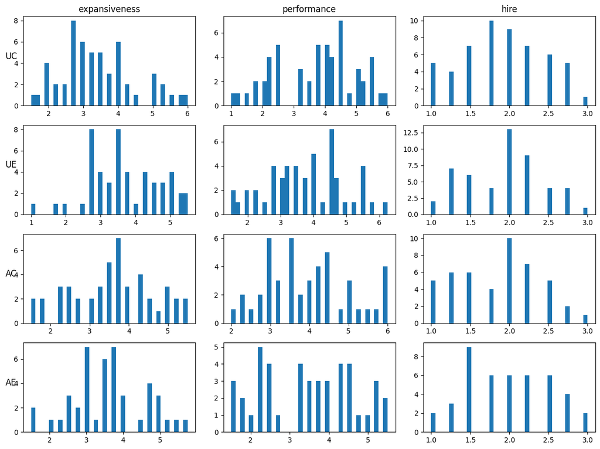

```python
fig, axs = plt.subplots(nrows=len(conds), ncols=len(cols), figsize=(12, 9))

for i in range(len(conds)):
    cond = conds[i]
    axs[i, 0].set_ylabel(cond, rotation=0, size='large')
    for j in range(len(cols)):
        col = cols[j]
        if i == 0:
            axs[i, j].set_title(col)
        axs[i, j].hist(df2[df2.cond == cond][col].values, bins=35)

fig.tight_layout()
```

#### 2. Equal Variances

The variances for each group should be roughly equal.

```python
df2.groupby("cond").std()
```

| cond | expansiveness | performance | hire |
| --- | --- | --- | --- |
| AC | 1.066168 | 1.082190 | 0.536387 |
| AE | 1.017860 | 1.192202 | 0.537538 |
| UC | 1.057526 | 1.284015 | 0.531995 |
| UE | 1.011175 | 1.169783 | 0.501427 |

#### ANOVA Results

```python
awareness = ["aware" if cond[0] == 'A' else "unaware" for cond in df2.cond.values]
body_pos = ["expansive" if cond[1] == 'E' else "constrictive" for cond in df2.cond.values]
df = pd.DataFrame({
    "awareness": awareness,
    "body_pos": body_pos,
    "expansiveness": df2.expansiveness.values,
    "performance": df2.performance.values,
    "hire": df2.hire.values
})
df
```

|  | awareness | body_pos | expansiveness | performance | hire |
| --- | --- | --- | --- | --- | --- |
| 0 | unaware | constrictive | 5.50 | 6.00 | 1.00 |
| 1 | unaware | expansive | 3.25 | 2.75 | 2.25 |
| 2 | unaware | expansive | 3.00 | 4.75 | 1.75 |
| 3 | aware | constrictive | 3.75 | 3.25 | 2.25 |
| 4 | unaware | constrictive | 2.50 | 4.25 | 2.00 |
| ... | ... | ... | ... | ... | ... |
| 189 | aware | expansive | 3.00 | 2.25 | 2.50 |
| 190 | unaware | constrictive | 2.75 | 3.75 | 1.75 |
| 191 | unaware | constrictive | 5.25 | 4.50 | 1.75 |
| 192 | unaware | expansive | 2.75 | 2.75 | 2.50 |
| 193 | aware | expansive | 3.00 | 1.50 | 2.75 |

194 rows × 5 columns

```python
import statsmodels.api as sm
from statsmodels.formula.api import ols

def get_anova_results(df: pd.DataFrame, dep_var: str):
    model = ols(f"{dep_var} ~ C(awareness) + C(body_pos) + C(awareness):C(body_pos)", data=df).fit()
    anova_table = sm.stats.anova_lm(model, typ=2)
    return anova_table
```

#### Expansiveness

```python
get_anova_results(df, "expansiveness")
```

|  | sum_sq | df | F | PR(>F) |
| --- | --- | --- | --- | --- |
| C(awareness) | 0.080182 | 1.0 | 0.074288 | 0.785489 |
| C(body_pos) | 0.999186 | 1.0 | 0.925730 | 0.337198 |
| C(awareness):C(body_pos) | 0.630923 | 1.0 | 0.584541 | 0.445487 |
| Residual | 205.076288 | 190.0 | NaN | NaN |

#### Performance

```python
get_anova_results(df, "performance")
```

|  | sum_sq | df | F | PR(>F) |
| --- | --- | --- | --- | --- |
| C(awareness) | 0.017850 | 1.0 | 0.012643 | 0.910593 |
| C(body_pos) | 2.136746 | 1.0 | 1.513440 | 0.220136 |
| C(awareness):C(body_pos) | 3.706089 | 1.0 | 2.624992 | 0.106852 |
| Residual | 268.251022 | 190.0 | NaN | NaN |

#### Hire

```python
get_anova_results(df, "hire")
```

|  | sum_sq | df | F | PR(>F) |
| --- | --- | --- | --- | --- |
| C(awareness) | 0.006727 | 1.0 | 0.024257 | 0.876399 |
| C(body_pos) | 0.256088 | 1.0 | 0.923421 | 0.337800 |
| C(awareness):C(body_pos) | 0.136320 | 1.0 | 0.491554 | 0.484093 |
| Residual | 52.691727 | 190.0 | NaN | NaN |

### Final Remarks

From the results above, we know that there are no statistical significance (all p-values are > 0.05) for each measure (i.e., expansiveness, performance, and hire).

### Please export this file to HTML and submit it to NTU COOL before next Friday (2023/9/15).